# An introduction into scoring

8/17/2020

## Scoring rules

- Lots of highly technical mathematics in the literature
- Not as much “common sense” interpretation

## Setup

- Forecaster
- Forecast
- Scoring Rule
- Goal: Develop a scoring rule so that in a competetition between forecasters, the forecasters are incentivized to forecast their true belief.

## Example: Talking heads

- Many news pundits make outrageous forecasts
  - May or may not be their true beliefs
  - Very little penalty for wrong forecast
  - Huge reward if outrageous forecast happens
- Most of these forecasts are wrong
  - The forecaster is not making calibrated predictions
  - The forecaster gets rewarded despite poor forecasting skills
  - The scoring rule isn’t working

## Properties of scoring rules

- What properties should we want in a forecast?
- We want **forecasts that are calibrated**
  - If the weather person says there is a 50% chance of rain, on average, there should be rain on 50% of these days.
  - Weather forecasts communicated to the public are **not** calibrated
  - You said there was a 5% chance of rain and it rained and I didn’t have my umbrella – You said it wouldn’t rain!

## Properties of scoring rules

- We want **scoring rules that can distinguish between good and bad forecasters**
  - If one forecaster is better than another, does the socring rule select the better forecaster at least on average (mathematics-ese: under expectation)
  - Called proper scoring rules
  - The highest expected reward is obtained by reporting the true probability distribution
- [Really nice animation](https://en.wikipedia.org/wiki/File:Scoring_functions.gif)

## Properties of scoring rules

- **Strictly** proper scoring rules will, on average choose the better forecast
  - Forecaster Alice forecasts a probability of 0.8 with a 90% CI of (0.75, 0.85)
  - Forecaster Bob forecasts a probability of 0.8 with a 90% CI of (0.70, 0.9)
  - The true value is 0.8
- Which was the better forecast?
- Which forecaster has the better mean square error? Mean absolute error?

## Properties of scoring rules

- Scoring rules should not just reward **accurate** forecasts but should also reward **precise** forecasts

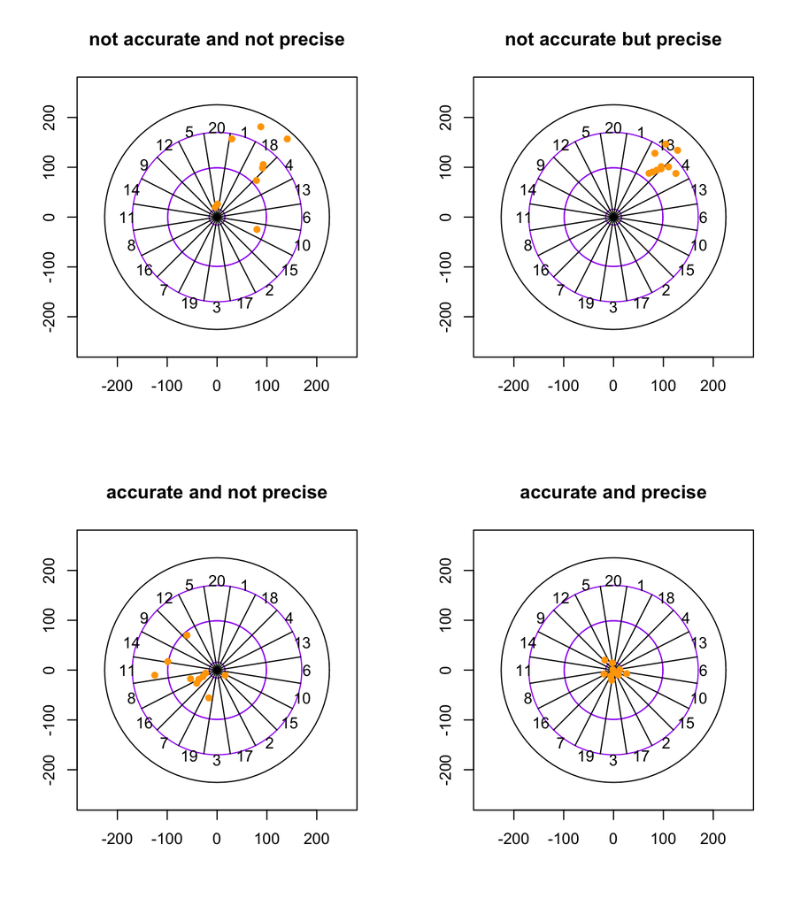

## Scoring rule language can sometimes be confusing

- **Probabilistic forecast:**
  - Scoring rule literature:
    - forecasting the probability of an event happening
    - 35% chance of rain tomorrow
  - Bayesian forecasting literature:
    - the forecast is a probability distribution
    - \(y_t \sim N(\mu, \sigma^2)\)
- **Point forecast**
  - Single valued forecasts
    - \(\hat{y}_t = 2.2\)

## How do we get point forecasts anyway?

- Point forecasts **start with a distribution!**

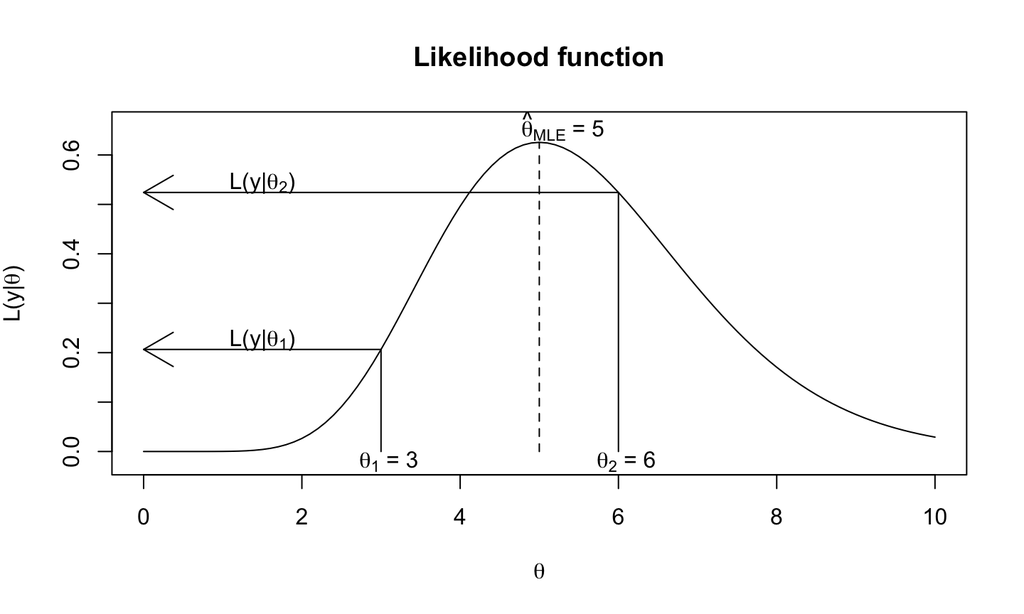

## How do we get point forecasts anyway?

- **Consistent** scoring functions are a subset of proper scoring rules that depend on the predictive distribution through a function.
  - If the scoring rule is mean square error (MSE), the consistent function is the forecast distribution mean
  - If the scoring rule is mean absolute error (MAE), the consistent function is the forecast distribution median
- If you use maximum *a posteriori* inference in a Bayesian model, which score is consistent (and therefore proper?)

## The problem of evaluating point forecasts

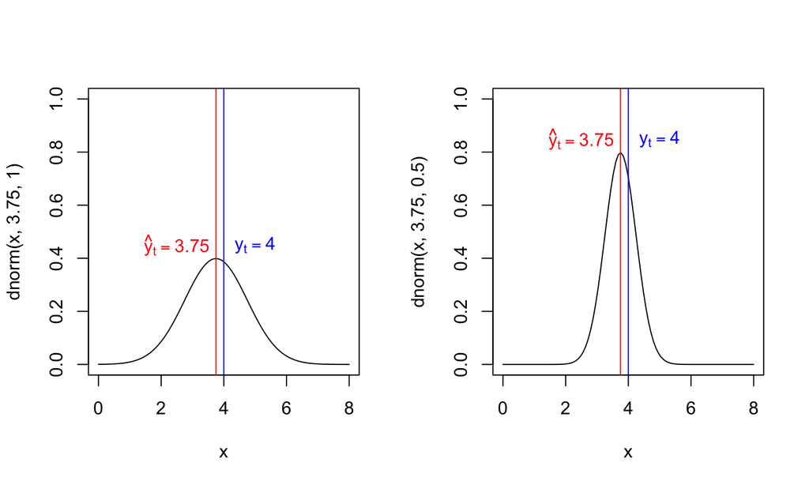

## The problem of evaluating point forecasts

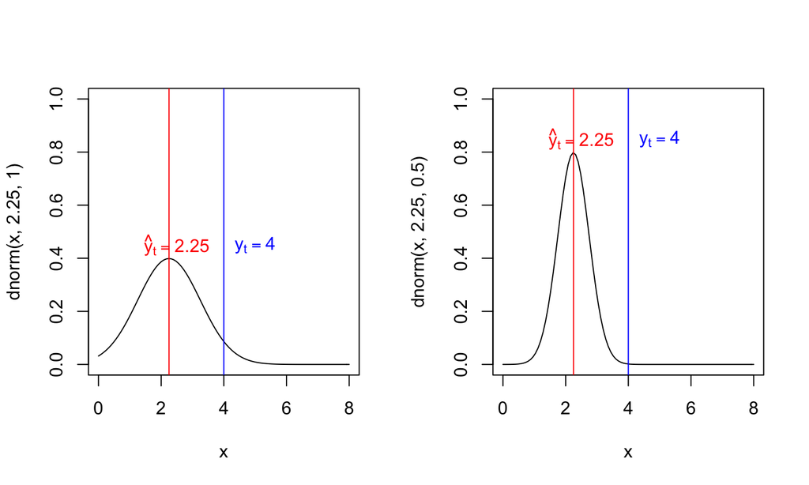

## Problem with point forecasts

- Proper scoring rules on point forecasts measure **calibration**
- **Sharpness** is important when evaluating a forecast
- Ideas for measuring sharpness?

## Work in progress

### TBD

- Prediction-based scoring rules
  - MSE, MAE, AUC, CRPS, elpd (approximate loo-cv)

## Work in progress

### TBD

- MSE

  \[ \begin{align*} (\hat{y}_t - y_t)^2 \end{align*} \]
- MAE

  \[ \begin{align*} |\hat{y}_t - y_t| \end{align*} \]

## Work in progress

### TBD

- Why CRPS is a good scoring rule
  - Can think of CRPS as a combination of how good the point forecast is and how reliable the forecast distribution is.
- https://arxiv.org/pdf/1709.04743.pdf

## WIP

### CRPS

Let \(y_t\) be an observed value indexed by \(t\). Let \({F}(\hat{y_t})\) be the cumulative forecast distribution (often approximated by MCMC). Then CRPS is

\[ \begin{align*} CRPS & = \int_{-\infty}^{\infty} \left( F(\hat{y_t}) - I\left\{ \hat{y}_t > y_t\right\} \right)^2 \,d \hat{y}_t \end{align*} \]

## WIP

### CRPS

When using MCMC to estimate \(F(\hat{y}_t)\) with \(K\) MCMC samples \(\{\hat{y}_t^{(1)}, \ldots, \hat{y}_t^{(K)}\}\), the CRPS can be written as

\[ \begin{align*} CRPS & = \frac{1}{K^2} \sum_{k=1}^K \sum_{k'=1}^K |\hat{y}_t^{(k)} - \hat{y}_t^{(k')}| - \frac{1}{K} \sum_{k=1}^K |\hat{y}_t^{(k)} - y_t| \end{align*} \]

- The first sum is a measure of how spread out the forecast distribution is.
- The second sum is a measure of how far each probabilistic forecast element is from the observed value.
- If there is a single (point forecast – K = 1), CRPS reducs to MAE (double check conditions)

## WIP

### LOO

- Fully Bayesian MCMC allows for a single MCMC fit to approximate leave-one-out cross validation
- Easy to implement within the [`stan` ecosystem](https://mc-stan.org/)
- http://mc-stan.org/loo/index.html

## WIP

### Other than scoring how do you validate

- Probability Integral Transform (PIT)

[figure not shown]

## WIP

### Other than scoring how do you validate

## Seems like a lot of work to me… Why bother?

- Can we find an example dataset or simulation that can illustrate the results?